# datasetgen_delitosvalidadosRelatosPoliciaFge

## MACHINE LEARNING MODEL TO PREDICT LABELS IN ROBBERY DATASET

Date: 2023-11-30

Coder:Lenin G. Falconi

The purpose of this notebook is to generate the dataset to train a LLM model to predict labels according to the information from the crime story. The crime story to be used corresponds to that saved both in Police report and Prossecutor Office

```python
import pandas as pd
import numpy as np
import os
from utils import conectar_sql, extraer_relato
from sqlalchemy import text

dir_root = os.getcwd()
dir_root
```

```
'/home/falconiel/CodePrograms/clasificaion_robos_fge'
```

```python
conn = conectar_sql()
```

```
conectando con big data database....
<sqlalchemy.engine.base.Connection object at 0x7fd205387610>
```

Las etiquetas para el entrenamiento son 2:

1. delitos_seguimiento: son 6 desagregaciones sobre las que realizan seguimiento
2. delitos_validados: de acuerdo a una reunion se quedan en 10 categorías mas 4 categorias que formaran una nueva categoría denominada otros robos. En este caso las categorías a utilizar son:

```python
DELITOS_VALIDADOS_CAT10 = ["ROBO A PERSONAS",
                           "ROBO A DOMICILIO",
                           "ROBO DE BIENES, ACCESORIOS Y AUTOPARTES DE VEHICULOS",
                           "ROBO DE MOTOS",
                           "ROBO DE CARROS",
                           "ROBO A UNIDADES ECONOMICAS",
                           "ROBO A INSTITUCIONES EDUCATIVAS",
                           "ROBO A EMBARCACIONES DE ESPACIOS ACUATICOS",
                           "ROBO EN INSTITUCIONES PUBLICAS",
                           "ROBO A ESTABLECIMIENTOS DE COLECTIVOS U ORGANIZACIONES SOCIALES"]

DELITOS_OTROS_ROBOS = ["ROBO A INSTITUCIONES DE SALUD",
                       "ROBO EN EJES VIALES O CARRETERAS",
                       "ROBO A ENTIDADES FINANCIERAS"]
```

```python
# query = text("SELECT `NDD`,`Fecha_Registro`,`Hora_Registro`,`Fecha_Incidente`,`Hora_Incidente`,`Menor`,`Mayor`,`Tentativa`,`Sector`,`Modalidad`,`Presunto_Delito`,`Brigada_PJ`,`Fiscalia`,`Fiscalia_Especializada`,`Ciudad`,`Parroquia`,bar_descripcion,`Fuero`,`Lugar`,`Tipo_Delito_PJ`,`Origen`,`Tipo`,`Bien`,`Tipo_Involucrado`,edad_actual,estatus_migratorio,autodef_etnica,`FyNF`,desagregacion,lugar_desagregacion,modalidad_desagregacion,cod_provincia,pro_descripcion,cod_parroquia,cod_canton,cod_barrio,fisbrigas,numero_fiscalia,edificio,mes_i,`ANIO_I`,desagregacion_1,delitos_validados,delitos_seguimiento,`PROVIN`,`Cant_5`,`Canton`,sexo,`Estado`,`Desplegar`,`Vehiculo`,genero,`Fecha_Nacimiento`,uni_codigo,paises,longitud,latitud,`FASE_PROCESAL_ACTUAL`,`PROXIMA_FASE_PROCESAL`,`PAIS_INVOLUCRADO`,`ART`,gen_secuencial_codigo FROM robos_2014_08012023;")
query_comision = text("""
SELECT
r.NDD ,
r.Tipo_Delito_PJ ,
r.delitos_seguimiento,
r.delitos_validados
FROM reportes.robos_2014_08012023 r
WHERE r.Tipo_Delito_PJ = 'ROBO';
-- LIMIT 70000;
""")
robos_comision_df = pd.read_sql(query_comision,conn)
robos_comision_df.shape
```

```
(735045, 4)
```

```python
robos_comision_df.sample(5)
```

|  | NDD | Tipo_Delito_PJ | delitos_seguimiento | delitos_validados |
| --- | --- | --- | --- | --- |
| 54365 | 130801814060016 | ROBO | ROBO A PERSONAS | ROBO A PERSONAS |
| 100431 | 060101815040033 | ROBO | ROBO A DOMICILIO | ROBO A DOMICILIO |
| 516221 | 010101820100023 | ROBO | SIN INFORMACION | TENTATIVA DE ROBO |
| 321816 | 120501817080005 | ROBO | ROBO A DOMICILIO | ROBO A DOMICILIO |
| 510912 | 230101819020725 | ROBO | ROBO A PERSONAS | ROBO A PERSONAS |

Los relatos se extraen de la base de datos que contiene tanto los relatos de Fiscalia como de Policía. Para esto se puede limitar la obtención de datos consultando únicamente las Ndds disponibles en el dataset de comisión

```python
ndds_comision = robos_comision_df.NDD.unique().tolist()
len(ndds_comision)
```

```
735045
```

```python
query_relatos = text(f"""SELECT robos.NDD,
                        robos.Presunto_Delito,
                        robos.RelatoPolicia,
                        robos.RelatoFiscalia,
                        robos.cantidadPalabras_RelatoPolicia,
                        robos.cantidadPalabras_RelatoFiscalia,
                        robos.delitos_validados_comision,
                        robos.delitos_seguimiento_comision
                        FROM reportes.`relatosPoliciaSiaf_20230830` robos
                        WHERE robos.NDD IN {tuple(ndds_comision)};

""")
# print(query_relatos)
relatos_df = pd.read_sql(query_relatos, conn)
relatos_df.shape
```

```
(725079, 8)
```

```python
relatos_df.sample(5)
```

|  | NDD | Presunto_Delito | RelatoPolicia | RelatoFiscalia | cantidadPalabras_RelatoPolicia | cantidadPalabras_RelatoFiscalia | delitos_validados_comision | delitos_seguimiento_comision |
| --- | --- | --- | --- | --- | --- | --- | --- | --- |
| 310543 | 180101822050138 | ROBO | POR MEDIO DEL PRESENTE ME PERMITO PONER EN SU ... | SE AVOCA CONOCIMIENTO DE EXPEDIENTE FISCAL POR... | 556 | 39 | N/A | N/A |
| 318651 | 030301822040049 | ROBO | SEÑOR FISCAL EL DÍA LUNES 18 DE ABRIL DEL 202... | SEÑOR FISCAL EL DÍA LUNES 18 DE ABRIL DEL 2022... | 88 | 92 | ROBO A DOMICILIO | ROBO A PERSONAS |
| 557241 | 170101814115285 | ROBO | ES EL CASO SEÑOR FISCAL, QUE EL DÍA DE HOY SÁB... | Es el caso señor Fiscal, que el día de hoy sáb... | 200 | 209 | ROBO DE CARROS | ROBO DE CARROS |
| 680137 | 210101817080168 | ROBO | ES EL CASO SEÑOR FISCAL QUE EL DÍA DOMINGO 20 ... | ES EL CASO SEÑOR FISCAL QUE EL DÍA DOMINGO 20 ... | 126 | 133 | ROBO A DOMICILIO | ROBO A DOMICILIO |
| 520443 | 070101816060795 | ROBO | MEDIANTE EL PRESENTE ME PERMITO HACERLE CONOCE... | ADJUNTO PARTE POLICIAL NRO. SURCP3069333 POR ... | 177 | 21 | ROBO A PERSONAS | ROBO A PERSONAS |

Dado que se ha actualizado el tipo penal con respecto a lo que registro SIAF en la fecha de corte en la que se generó el dataset de relatos, se plantea el excluir tipos penales distintos de Robo

```python
relatos_robo_df = relatos_df[relatos_df.Presunto_Delito=="ROBO"]
relatos_robo_df.shape, relatos_df.shape
```

```
((723435, 8), (725079, 8))
```

Observemos si existen delitos validados o delitos comision nulos

```python
relatos_robo_df.delitos_seguimiento_comision.isna().sum(), relatos_robo_df.delitos_validados_comision.isna().sum()
```

```
(24, 24)
```

```python
relatos_robo_df[relatos_robo_df.delitos_seguimiento_comision.isna()].head()
```

|  | NDD | Presunto_Delito | RelatoPolicia | RelatoFiscalia | cantidadPalabras_RelatoPolicia | cantidadPalabras_RelatoFiscalia | delitos_validados_comision | delitos_seguimiento_comision |
| --- | --- | --- | --- | --- | --- | --- | --- | --- |
| 211629 | 130301822010054 | ROBO | SEÑORA FISCAL POR MEDIO DE LA PRESENTE REMITO ... | Señor/a Fiscal por medio de la presente remito... | 306 | 28 | None | None |
| 211988 | 170101822013983 | ROBO | ES ASÍ SEÑOR FISCAL QUE CON FECHA 29 DE DICIE... | Se adjunta denuncia escrita presentado por Iva... | 308 | 13 | None | None |
| 252194 | 230101822090505 | ROBO | POR MEDIO DEL PRESENTE PONGO EN SU CONOCIMIENT... | Por medio del presente parte policial20220917... | 420 | 28 | None | None |
| 252583 | 120101822110320 | ROBO | ES EL CASO SEÑOR FISCAL QUE EL DÍA DE HOY JUE... | Es el caso señor fiscal que el día de hoy juev... | 170 | 177 | None | None |
| 254036 | 170101822092881 | ROBO | PROCEDIMIENTO DIRECTOAUDIENCIA 05 DE OCTUBRE 2... | PROCEDIMIENTO DIRECTOAUDIENCIA 05 DE OCTUBRE 2... | 9 | 9 | None | None |

Se realiza el merge para determinar comparar que la etiqueta sea la etiqueta original humana de la comision

```python
robos_df = pd.merge(relatos_robo_df, robos_comision_df, on='NDD', how='inner', suffixes=['_relatos', '_comision'])
robos_df.shape, relatos_robo_df.shape, robos_comision_df.shape
```

```
((723435, 11), (723435, 8), (735045, 4))
```

```python
robos_df.info()
```

```
<class 'pandas.core.frame.DataFrame'>
Int64Index: 723435 entries, 0 to 723434
Data columns (total 11 columns):
 #   Column                           Non-Null Count   Dtype
---  ------                           --------------   -----
 0   NDD                              723435 non-null  object
 1   Presunto_Delito                  723435 non-null  object
 2   RelatoPolicia                    723435 non-null  object
 3   RelatoFiscalia                   723435 non-null  object
 4   cantidadPalabras_RelatoPolicia   723435 non-null  int64
 5   cantidadPalabras_RelatoFiscalia  723435 non-null  int64
 6   delitos_validados_comision       723411 non-null  object
 7   delitos_seguimiento_comision     723411 non-null  object
 8   Tipo_Delito_PJ                   723435 non-null  object
 9   delitos_seguimiento              723435 non-null  object
 10  delitos_validados                723435 non-null  object
dtypes: int64(2), object(9)
memory usage: 66.2+ MB
```

```python
robos_df['check_delitos_seguimiento'] = robos_df.apply(lambda x: 'OK' if x['delitos_seguimiento_comision']==x['delitos_seguimiento'] else 'DIFF', axis = 1 )
robos_df['check_delitos_validados'] = robos_df.apply(lambda x: 'OK' if x['delitos_validados_comision']==x['delitos_validados'] else 'DIFF', axis=1 )
```

```python
robos_df.check_delitos_seguimiento.value_counts()
```

```
OK      679778
DIFF     43657
Name: check_delitos_seguimiento, dtype: int64
```

```python
robos_df.check_delitos_validados.value_counts()
```

```
OK      689076
DIFF     34359
Name: check_delitos_validados, dtype: int64
```

Dado que el dataset que se guardo como reportes.`relatosPoliciaSiaf_20230830` y estos pueden incluir las prediecciones del modelo realizadas en 2023. Sin embargo, para evitar esto, la lectura de datos se hizo con respecto de las ndds que existen en la tabla reportes.robos_2014_08012023; Sin embargo, se deber observar qeu durante el transcurso del 2023 se realiaron ajustes al año 2021. Por tanto habría que observar en una muestra de Ndds afectadas cuál es su última fecha de actualización de valor para descartar que esta haya sido ya predicha por el modelo.

```python
robos_df[['NDD', 'cantidadPalabras_RelatoFiscalia', 'delitos_seguimiento_comision', 'delitos_seguimiento', 'check_delitos_seguimiento']][robos_df.check_delitos_seguimiento=="DIFF"].sample(5)
```

|  | NDD | cantidadPalabras_RelatoFiscalia | delitos_seguimiento_comision | delitos_seguimiento | check_delitos_seguimiento |
| --- | --- | --- | --- | --- | --- |
| 334522 | 170101822013559 | 389 | ROBO A UNIDADES ECONOMICAS | ROBO A PERSONAS | DIFF |
| 289357 | 090101822095282 | 228 | ROBO A UNIDADES ECONOMICAS | ROBO A UNIDADES ECONÓMICAS | DIFF |
| 250055 | 090101822075053 | 37 | N/A | SIN INFORMACION | DIFF |
| 334645 | 120701822020023 | 112 | ROBO A UNIDADES ECONOMICAS | ROBO A UNIDADES ECONÓMICAS | DIFF |
| 320631 | 011001822030001 | 65 | ROBO A PERSONAS | SIN INFORMACION | DIFF |

En este sentido lo que se puede optar por realizar es utlizar la columna delitos_seguimiento y delito_validados que provinien de dataset robos_2014_08012023 y descartar las columnas delitos_seguimiento_comision y delitos_validados_comision que provienen del dataset de relatos. Sencillamente confirmemos las fechas de las ndds afectadas. Como ejemplo puede utilizar los índices: 281773,273241,326639,249959,258103, en donde se observa que la cantdiad de palabras del relato fiscalía es inferior a 50 y por ende tienen la etiqueta N/A en vez de una categoria

```python
posibles_ndds_predichas_con_modelo = robos_df.NDD[(robos_df.check_delitos_seguimiento=="DIFF")|
                                                   (robos_df.check_delitos_validados=="DIFF")].to_list()
len(posibles_ndds_predichas_con_modelo)
```

```
45567
```

```python
import random
this_sample = random.sample(posibles_ndds_predichas_con_modelo, 10)

this_query = f"select * from reportes.robos_2014_08012023 r where r.NDD in {tuple(this_sample)}"
this_result = pd.read_sql(this_query, conn)
this_result[['NDD', 'Fecha_Registro', 'delitos_seguimiento', 'delitos_validados']]
```

|  | NDD | Fecha_Registro | delitos_seguimiento | delitos_validados |
| --- | --- | --- | --- | --- |
| 0 | 090301822110051 | 2022-11-24 | ROBO DE CARROS | ROBO DE CARROS |
| 1 | 091001822100106 | 2022-10-08 | ROBO A PERSONAS | ROBO A PERSONAS |
| 2 | 170101822092105 | 2022-09-12 | ROBO A PERSONAS | ROBO A PERSONAS |
| 3 | 170101822080256 | 2022-08-02 | ROBO A PERSONAS | ROBO A PERSONAS |
| 4 | 090101822010611 | 2022-01-05 | ROBO A PERSONAS | ROBO A PERSONAS |
| 5 | 170101822074781 | 2022-07-26 | ROBO A UNIDADES ECONÓMICAS | ROBO A UNIDADES ECONOMICAS |
| 6 | 131001822030004 | 2022-03-08 | ROBO A UNIDADES ECONÓMICAS | ROBO A UNIDADES ECONOMICAS |
| 7 | 090901822040037 | 2022-04-13 | ROBO DE BIENES, ACCESORIOS Y AUTOPARTES DE VEH... | ROBO DE BIENES, ACCESORIOS Y AUTOPARTES DE VEH... |
| 8 | 090701822120374 | 2022-12-22 | ROBO A PERSONAS | ROBO A PERSONAS |
| 9 | 230101822100046 | 2022-10-03 | ROBO DE CARROS | ROBO DE CARROS |

Esta confirmado que robos_delitos_seguimiento_comision y robos_delitos_validados_comision tendrían que ser descartados para los fines del entrenamiento

```python
robos_df[['NDD', 'delitos_seguimiento_comision', 'delitos_validados_comision']][robos_df.NDD.isin(['091001822110015', '230101822110767', '090101822123267'])]
```

|  | NDD | delitos_seguimiento_comision | delitos_validados_comision |
| --- | --- | --- | --- |
| 259447 | 090101822123267 | ROBO A UNIDADES ECONOMICAS | ROBO A UNIDADES ECONOMICAS |
| 277502 | 230101822110767 | N/A | N/A |
| 282295 | 091001822110015 | ROBO DE BIENES, ACCESORIOS Y AUTOPARTES DE VEH... | ROBO DE BIENES, ACCESORIOS Y AUTOPARTES DE VEH... |

```python
# relatos_df = extraer_relato(robos_df.NDD.to_list(), conn)
# relatos_df.shape
```

```python
# idx = np.random.randint(0, len(relatos_df))
# idx
```

## Formateando el relato

Se procede a aplicar formato a los relatos de Policia y de Fiscalia

```python
from src.utils import format_crimestory
format_crimestory(dataf=robos_df, relato_label='RelatoPolicia')
format_crimestory(dataf=robos_df, relato_label='RelatoFiscalia')
```

```
2023-12-05 15:17:35.307006: I tensorflow/core/platform/cpu_feature_guard.cc:193] This TensorFlow binary is optimized with oneAPI Deep Neural Network Library (oneDNN) to use the following CPU instructions in performance-critical operations:  SSE4.1 SSE4.2 AVX AVX2 FMA
To enable them in other operations, rebuild TensorFlow with the appropriate compiler flags.
```

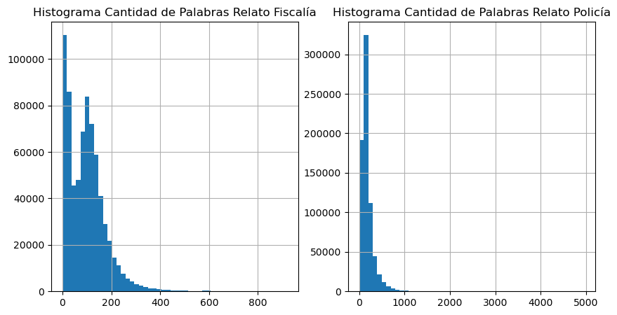

```python
import matplotlib.pyplot as plt

# create two subplots
fig, (ax1, ax2) = plt.subplots(1, 2, figsize=(10, 5))

# plot the first graph
robos_df.cantidadPalabras_RelatoFiscalia.hist(bins=50, ax=ax1)
ax1.set_title('Histograma Cantidad de Palabras Relato Fiscalía')
ax1.grid(True)
# plot the second graph
robos_df.cantidadPalabras_RelatoPolicia.hist(bins=50, ax=ax2)
ax2.set_title('Histograma Cantidad de Palabras Relato Policía')
ax2.grid(True)
# show the plots
# plt.grid()
plt.show()
```

```python
# import plotly_express as px
# px.histogram(relatos_df.cantidad_palabras, title='Word Count Histogram')
```

```python
# relatos_df[relatos_df.cantidad_palabras == relatos_df.cantidad_palabras.value_counts().max()]
```

```python
# relatos_df.cantidad_palabras.value_counts().max()
# relatos_df.cantidad_palabras.max()
```

```python
print("Estadística Relato Fiscalía")
robos_df.cantidadPalabras_RelatoFiscalia.describe()
```

```
Estadística Relato Fiscalía
```

```
count    723435.000000
mean         98.468313
std          77.589060
min           0.000000
25%          32.000000
50%          92.000000
75%         137.000000
max         920.000000
Name: cantidadPalabras_RelatoFiscalia, dtype: float64
```

```python
print("Estadística Relato Policía")
robos_df.cantidadPalabras_RelatoPolicia.describe()
```

```
Estadística Relato Policía
```

```
count    723435.000000
mean        181.059123
std         147.046437
min           0.000000
25%          97.000000
50%         138.000000
75%         214.000000
max        4956.000000
Name: cantidadPalabras_RelatoPolicia, dtype: float64
```

```python
robos_df[['NDD', 'RelatoFiscalia', 'RelatoPolicia', 'cantidadPalabras_RelatoFiscalia', 'cantidadPalabras_RelatoPolicia', 'delitos_seguimiento', 'delitos_validados']].loc[695]
```

```
NDD                                                                  110101815050069
RelatoFiscalia                     es el caso señor fiscal adjunto dos fojas util...
RelatoPolicia                      por medio del presente muy respetuosamente nos...
cantidadPalabras_RelatoFiscalia                                                   13
cantidadPalabras_RelatoPolicia                                                   216
delitos_seguimiento                                                 ROBO A DOMICILIO
delitos_validados                                                   ROBO A DOMICILIO
Name: 695, dtype: object
```

```python
# relatos_df[relatos_df.cantidad_palabras == 569]
```

```python
# print(relatos_df.RELATO.iloc[289])
```

```python
# relatos_df[(relatos_df.cantidad_palabras>=40)&(relatos_df.cantidad_palabras<60)].sample(5)
```

```python
# # 198
# print(relatos_df.RELATO.iloc[220])
```

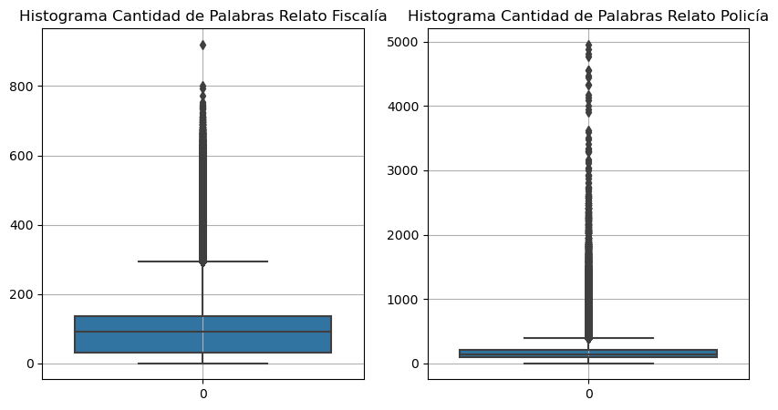

```python
import seaborn as sns
import plotly_express as px
# create two subplots
fig, (ax1, ax2) = plt.subplots(1, 2, figsize=(10, 5))
sns.boxplot(robos_df.cantidadPalabras_RelatoFiscalia, ax=ax1)
# px.box(robos_df.cantidadPalabras_RelatoFiscalia, ax=ax1)
ax1.set_title('Histograma Cantidad de Palabras Relato Fiscalía')
ax1.grid(True)

sns.boxplot(robos_df.cantidadPalabras_RelatoPolicia, ax=ax2)
ax2.set_title('Histograma Cantidad de Palabras Relato Policía')
ax2.grid(True)
```

Eventhough police records have more words than those of the prossecutor office, the majority of data is between quartiles $q_1$ to $q_3$ in values from 32 to 214. What's more number of words above 390 would correspond to outliers. What is interesting is to notice that police records havea $q_1$ of 97 which is better for our training and predictions. Also it is interseting to notice that we could suggest that the distance between $q1$ and $q3$ from any of the subsets is similar $d_{q_1-q_3}^{fge} \approx d_{q_1-q_3}^{pol}$

```python
import pandas as pd
import numpy as np

def print_boxplot_characteristics(df, column_name):
    # calculate the lower fence, quartiles, mean, and upper fence
    q1 = np.percentile(df[column_name], 25)
    q2 = np.percentile(df[column_name], 50)
    q3 = np.percentile(df[column_name], 75)
    iqr = q3 - q1
    lower_fence = q1 - 1.5 * iqr
    upper_fence = q3 + 1.5 * iqr
    mean = df[column_name].mean()

    # print the results
    print(f'Lower fence: {lower_fence:.2f}')
    print(f'Q1: {q1:.2f}')
    print(f'Q2 (median): {q2:.2f}')
    print(f'Q3: {q3:.2f}')
    print(f'Upper fence: {upper_fence:.2f}')
    print(f'Mean: {mean:.2f}')

print("Caracteristicas relato Policia")
print_boxplot_characteristics(df=robos_df, column_name='cantidadPalabras_RelatoPolicia')
print("Características Relato Fiscalia")
print_boxplot_characteristics(df=robos_df, column_name='cantidadPalabras_RelatoFiscalia')
```

```
Caracteristicas relato Policia
Lower fence: -78.50
Q1: 97.00
Q2 (median): 138.00
Q3: 214.00
Upper fence: 389.50
Mean: 181.06
Características Relato Fiscalia
Lower fence: -125.50
Q1: 32.00
Q2 (median): 92.00
Q3: 137.00
Upper fence: 294.50
Mean: 98.47
```

```python
dist_q1_q3_fge = 137-32
dist_q1_q3_pol = 214-97
lower_upper_fge = 294.5+125.5
lower_upper_pol = 389.5+78.5
dist_q1_q3_fge, dist_q1_q3_pol, lower_upper_fge, lower_upper_pol
```

```
(105, 117, 420.0, 468.0)
```

```python
dist_q1_q3_fge/lower_upper_fge, dist_q1_q3_pol/lower_upper_pol
```

```
(0.25, 0.25)
```

```python
# px.box(robos_df.cantidadPalabras_RelatoFiscalia)
```

```python
# px.box(robos_df.cantidadPalabras_RelatoFiscalia)
```

$data_i \in \; \mathcal{D} \; if\; len(data_i) \in 50<wordCound\leq 390$

```python
# relatos_100df = robos_df[(robos_df.cantidadPalabras_RelatoFiscalia<=300)&(robos_df.cantidadPalabras_RelatoFiscalia>50)]
# relatos_100df.shape, relatos_df.shape
relatos_ndd_fge = robos_df.NDD[(robos_df.cantidadPalabras_RelatoFiscalia>=50)&(robos_df.cantidadPalabras_RelatoFiscalia<=390)]
relatos_ndd_pol = robos_df.NDD[(robos_df.cantidadPalabras_RelatoPolicia>=50)&(robos_df.cantidadPalabras_RelatoPolicia<=390)]
total = set(relatos_ndd_fge).union(relatos_ndd_pol)
len(total)
# robos_df.head()
```

```
655664
```

```python
# relatos_outlierdf = relatos_df[relatos_df.cantidad_palabras>300]
# relatos_outlierdf.shape, relatos_df.shape
```

```python
# relatos_df[relatos_df.cantidad_palabras==relatos_df.cantidad_palabras.min()]
# relatos_df.cantidad_palabras.min()
```

## Transforming dataset to have only one column of text

Let us formalize how we are about to deal with data. Data is organized by the number of the crime notice named $ndd$. We have that for a record $ndd_i$ it is possible to find two accepted crime tales, one from fge and another from police. This could be named $text^{fge}_i$ and $text^{pol}_i$. Since $ndd_i$ is not important for training we should check that create a new row like a new case but with the other text and must be careful to notice they have the same label. Otherwise we may compromise the correct training of the model. Also for training and validation it could be handed that we have samples from both types of tales

```python
robos_df.shape
```

```
(723435, 13)
```

```python
robos_df.columns
```

```
Index(['NDD', 'Presunto_Delito', 'RelatoPolicia', 'RelatoFiscalia',
       'cantidadPalabras_RelatoPolicia', 'cantidadPalabras_RelatoFiscalia',
       'delitos_validados_comision', 'delitos_seguimiento_comision',
       'Tipo_Delito_PJ', 'delitos_seguimiento', 'delitos_validados',
       'check_delitos_seguimiento', 'check_delitos_validados'],
      dtype='object')
```

```python
robos_relato_siaf_df = robos_df[['NDD', 'Presunto_Delito', 'RelatoFiscalia', 'delitos_seguimiento', 'delitos_validados']].copy()
robos_relato_policia_df = robos_df[['NDD', 'Presunto_Delito', 'RelatoPolicia', 'delitos_seguimiento', 'delitos_validados']].copy()
robos_relato_siaf_df.rename(columns={'RelatoFiscalia':'Relato'}, inplace=True)
robos_relato_policia_df.rename(columns={'RelatoPolicia':'Relato'}, inplace=True)
```

```python
robos_relato_concat_df = pd.concat([robos_relato_siaf_df, robos_relato_policia_df])
robos_relato_concat_df.shape
```

```
(1446870, 5)
```

```python
robos_relato_concat_df.shape[0]/robos_df.shape[0]
```

```
2.0
```

```python
robos_relato_concat_df['cantidadPalabras'] = robos_relato_concat_df.Relato.apply(lambda x: len(x.split()))
```

We sort the dataset by the Ndd

```python
robos_relato_concat_df.sort_values(by='NDD', ascending=True, inplace=True)
```

```python
robos_relato_concat_df.head(20)
```

|  | NDD | Presunto_Delito | Relato | delitos_seguimiento | delitos_validados | cantidadPalabras |
| --- | --- | --- | --- | --- | --- | --- |
| 583803 | 010101814010030 | ROBO | el dia uno de enero de dos mil catorce a parti... | ROBO A PERSONAS | ROBO A PERSONAS | 123 |
| 583803 | 010101814010030 | ROBO | el dia uno de enero de dos mil catorce a parti... | ROBO A PERSONAS | ROBO A PERSONAS | 123 |
| 578609 | 010101814010041 | ROBO | es el caso señor fiscal que el dia de hoy a es... | ROBO A DOMICILIO | ROBO A DOMICILIO | 141 |
| 578609 | 010101814010041 | ROBO | es el caso señor fiscal que el dia de hoy a es... | ROBO A DOMICILIO | ROBO A DOMICILIO | 134 |
| 572203 | 010101814010072 | ROBO | por medio del presente me permito poner en su ... | ROBO A DOMICILIO | ROBO A DOMICILIO | 924 |
| 572203 | 010101814010072 | ROBO | adjunto parte policial numero 010 realizado po... | ROBO A DOMICILIO | ROBO A DOMICILIO | 20 |
| 599910 | 010101814010075 | ROBO | es el caso sr fiscal que el dia 02 de enero de... | ROBO A DOMICILIO | ROBO A DOMICILIO | 61 |
| 599910 | 010101814010075 | ROBO | es el caso sr fiscal que el dia 02 de enero de... | ROBO A DOMICILIO | ROBO A DOMICILIO | 61 |
| 579955 | 010101814010083 | ROBO | el dia de ayer dos de enero de dos mil catorce... | ROBO DE BIENES, ACCESORIOS Y AUTOPARTES DE VEH... | ROBO DE BIENES, ACCESORIOS Y AUTOPARTES DE VEH... | 66 |
| 579955 | 010101814010083 | ROBO | el dia de ayer dos de enero de dos mil catorce... | ROBO DE BIENES, ACCESORIOS Y AUTOPARTES DE VEH... | ROBO DE BIENES, ACCESORIOS Y AUTOPARTES DE VEH... | 66 |
| 575260 | 010101814010111 | ROBO | el dia viernes 03 de enero aproximadamente a l... | ROBO A PERSONAS | ROBO A PERSONAS | 58 |
| 575260 | 010101814010111 | ROBO | el dia viernes 03 de enero aproximadamente a l... | ROBO A PERSONAS | ROBO A PERSONAS | 56 |
| 598664 | 010101814010122 | ROBO | por ser la victima una ciudadana colombiana no... | ROBO A PERSONAS | ROBO A PERSONAS | 182 |
| 598664 | 010101814010122 | ROBO | por ser la victima una ciudadana colombiana no... | ROBO A PERSONAS | ROBO A PERSONAS | 190 |
| 631692 | 010101814010124 | ROBO | el dia de ayer sabado cuatro de enero del 2014... | ROBO DE CARROS | ROBO DE CARROS | 129 |
| 631692 | 010101814010124 | ROBO | el dia de ayer sabado cuatro de enero del 2014... | ROBO DE CARROS | ROBO DE CARROS | 136 |
| 558513 | 010101814010125 | ROBO | el dia de ayer sabado cuatro de enero del dos ... | ROBO DE MOTOS | ROBO DE MOTOS | 122 |
| 558513 | 010101814010125 | ROBO | el dia de ayer sabado cuatro de enero del dos ... | ROBO DE MOTOS | ROBO DE MOTOS | 129 |
| 625303 | 010101814010133 | ROBO | es el caso señor fiscal que yo me desperte a l... | SIN INFORMACION | OTROS ROBOS | 53 |
| 625303 | 010101814010133 | ROBO | es el caso señor fiscal que yo me desperte a l... | SIN INFORMACION | OTROS ROBOS | 55 |

```python
robos_df[robos_df.NDD.isin(robos_relato_concat_df.NDD.to_list()[:20])]
```

|  | NDD | Presunto_Delito | RelatoPolicia | RelatoFiscalia | cantidadPalabras_RelatoPolicia | cantidadPalabras_RelatoFiscalia | delitos_validados_comision | delitos_seguimiento_comision | Tipo_Delito_PJ | delitos_seguimiento | delitos_validados | check_delitos_seguimiento | check_delitos_validados |
| --- | --- | --- | --- | --- | --- | --- | --- | --- | --- | --- | --- | --- | --- |
| 558513 | 010101814010125 | ROBO | el dia de ayer sabado cuatro de enero del dos ... | el dia de ayer sabado cuatro de enero del dos ... | 122 | 129 | ROBO DE MOTOS | ROBO DE MOTOS | ROBO | ROBO DE MOTOS | ROBO DE MOTOS | OK | OK |
| 572203 | 010101814010072 | ROBO | por medio del presente me permito poner en su ... | adjunto parte policial numero 010 realizado po... | 918 | 20 | ROBO A DOMICILIO | ROBO A DOMICILIO | ROBO | ROBO A DOMICILIO | ROBO A DOMICILIO | OK | OK |
| 575260 | 010101814010111 | ROBO | el dia viernes 03 de enero aproximadamente a l... | el dia viernes 03 de enero aproximadamente a l... | 56 | 58 | ROBO A PERSONAS | ROBO A PERSONAS | ROBO | ROBO A PERSONAS | ROBO A PERSONAS | OK | OK |
| 578609 | 010101814010041 | ROBO | es el caso señor fiscal que el dia de hoy a es... | es el caso señor fiscal que el dia de hoy a es... | 135 | 142 | ROBO A DOMICILIO | ROBO A DOMICILIO | ROBO | ROBO A DOMICILIO | ROBO A DOMICILIO | OK | OK |
| 579955 | 010101814010083 | ROBO | el dia de ayer dos de enero de dos mil catorce... | el dia de ayer dos de enero de dos mil catorce... | 66 | 66 | ROBO DE BIENES, ACCESORIOS Y AUTOPARTES DE VEH... | ROBO DE BIENES, ACCESORIOS Y AUTOPARTES DE VEH... | ROBO | ROBO DE BIENES, ACCESORIOS Y AUTOPARTES DE VEH... | ROBO DE BIENES, ACCESORIOS Y AUTOPARTES DE VEH... | OK | OK |
| 583803 | 010101814010030 | ROBO | el dia uno de enero de dos mil catorce a parti... | el dia uno de enero de dos mil catorce a parti... | 123 | 123 | ROBO A PERSONAS | ROBO A PERSONAS | ROBO | ROBO A PERSONAS | ROBO A PERSONAS | OK | OK |
| 598664 | 010101814010122 | ROBO | por ser la victima una ciudadana colombiana no... | por ser la victima una ciudadana colombiana no... | 180 | 190 | ROBO A PERSONAS | ROBO A PERSONAS | ROBO | ROBO A PERSONAS | ROBO A PERSONAS | OK | OK |
| 599910 | 010101814010075 | ROBO | es el caso sr fiscal que el dia 02 de enero de... | es el caso sr fiscal que el dia 02 de enero de... | 60 | 60 | ROBO A DOMICILIO | ROBO A DOMICILIO | ROBO | ROBO A DOMICILIO | ROBO A DOMICILIO | OK | OK |
| 625303 | 010101814010133 | ROBO | es el caso señor fiscal que yo me desperte a l... | es el caso señor fiscal que yo me desperte a l... | 54 | 56 | OTROS ROBOS | SIN INFORMACION | ROBO | SIN INFORMACION | OTROS ROBOS | OK | OK |
| 631692 | 010101814010124 | ROBO | el dia de ayer sabado cuatro de enero del 2014... | el dia de ayer sabado cuatro de enero del 2014... | 129 | 136 | ROBO DE CARROS | ROBO DE CARROS | ROBO | ROBO DE CARROS | ROBO DE CARROS | OK | OK |

The small variations on the number of words are due to the application of the format of crime story where punctuation and special characters are removed

```python
del robos_relato_policia_df
del robos_relato_siaf_df
```

Finally let us check how the new Relato column behaves and get only a dataset with enough text to be trained. Actually it could be interesting to not remove the punctuation and train the model and look for differences

```python
robos_relato_concat_df.cantidadPalabras.describe()
```

```
count    1.446870e+06
mean     1.435183e+02
std      1.295312e+02
min      0.000000e+00
25%      7.400000e+01
50%      1.170000e+02
75%      1.750000e+02
max      5.102000e+03
Name: cantidadPalabras, dtype: float64
```

```python
print_boxplot_characteristics(df=robos_relato_concat_df, column_name='cantidadPalabras')
```

```
Lower fence: -77.50
Q1: 74.00
Q2 (median): 117.00
Q3: 175.00
Upper fence: 326.50
Mean: 143.52
```

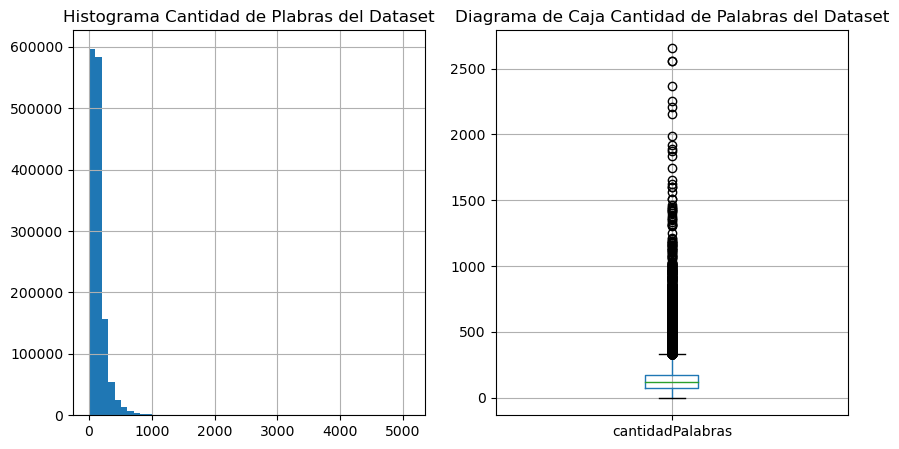

```python
fig, (ax1, ax2) = plt.subplots(1,2, figsize=(10,5))
robos_relato_concat_df.cantidadPalabras.hist(bins=50, ax=ax1)
ax1.set_title('Histograma Cantidad de Plabras del Dataset')
ax1.grid(True)

# sns.boxplot(robos_relato_concat_df.cantidadPalabras, ax=ax2)
robos_relato_concat_df.sample(36867).boxplot(column='cantidadPalabras', ax=ax2)
ax2.set_title('Diagrama de Caja Cantidad de Palabras del Dataset')
ax2.grid(True)
```

```python
LOW_LIMIT = 50
HIGH_LIMIT = 400
```

```python
robos_relato_concat_df.shape
```

```
(1446870, 6)
```

```python
robos_relato_selected = robos_relato_concat_df[(robos_relato_concat_df.cantidadPalabras>=LOW_LIMIT)
                                              &(robos_relato_concat_df.cantidadPalabras<=HIGH_LIMIT)]
robos_relato_selected.shape
```

```
(1140728, 6)
```

```python
robos_relato_selected.shape[0]/robos_relato_concat_df.shape[0]*100
```

```
78.84108454802436
```

```python
not_included = robos_relato_concat_df[(robos_relato_concat_df.cantidadPalabras<LOW_LIMIT)|(robos_relato_concat_df.cantidadPalabras>HIGH_LIMIT)].shape[0]
not_included, not_included/robos_relato_concat_df.shape[0]*100
```

```
(306142, 21.158915451975645)
```

The 79% of the data is used to generate the dataset

## Getting Labels

```python
# dataset = pd.merge(relatos_100df, robos_df, on='NDD', how='inner')
# dataset.shape, relatos_100df.shape, robos_df.shape
```

```python
dataset = robos_relato_selected.copy()
del robos_relato_selected
dataset.info()
```

```
<class 'pandas.core.frame.DataFrame'>
Int64Index: 1140728 entries, 583803 to 252840
Data columns (total 6 columns):
 #   Column               Non-Null Count    Dtype
---  ------               --------------    -----
 0   NDD                  1140728 non-null  object
 1   Presunto_Delito      1140728 non-null  object
 2   Relato               1140728 non-null  object
 3   delitos_seguimiento  1140728 non-null  object
 4   delitos_validados    1140728 non-null  object
 5   cantidadPalabras     1140728 non-null  int64
dtypes: int64(1), object(5)
memory usage: 60.9+ MB
```

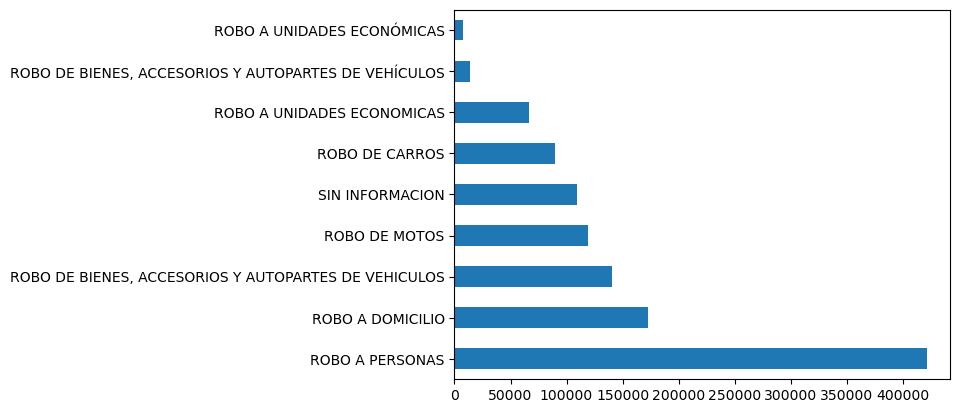

```python
dataset.delitos_seguimiento.value_counts().plot.barh()
```

```python
dataset.delitos_seguimiento.isna().sum(), dataset.delitos_validados.isna().sum()
```

```
(0, 0)
```

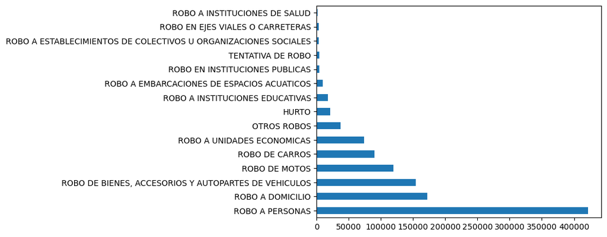

```python
dataset.delitos_validados.value_counts().head(15).plot.barh()
```

It is notorius unbalanced dataset. Is there a way to balance data accross the classes? I am sure I should use pandas get dummies in order to get one-hot encoding. I am yet not sure how this goes with huggien faces. I will try to approaches. Moreover some of the classes are repeated. Because of that we have to make some cleaning.

Notice that delitos_validados has more than the agreed number of categories

```python
dataset.delitos_seguimiento.unique().tolist()
```

```
['ROBO A PERSONAS',
 'ROBO A DOMICILIO',
 'ROBO DE BIENES, ACCESORIOS Y AUTOPARTES DE VEHICULOS',
 'ROBO DE CARROS',
 'ROBO DE MOTOS',
 'SIN INFORMACION',
 'ROBO A UNIDADES ECONOMICAS',
 'ROBO A UNIDADES ECONÓMICAS',
 'ROBO DE BIENES, ACCESORIOS Y AUTOPARTES DE VEHÍCULOS']
```

```python
dataset.delitos_seguimiento = dataset.delitos_seguimiento.str.replace('ECONÓMICAS', 'ECONOMICAS')
dataset.delitos_seguimiento = dataset.delitos_seguimiento.str.replace('VEHÍCULOS', 'VEHICULOS')
```

```python
dataset.delitos_seguimiento.unique().tolist()
```

```
['ROBO A PERSONAS',
 'ROBO A DOMICILIO',
 'ROBO DE BIENES, ACCESORIOS Y AUTOPARTES DE VEHICULOS',
 'ROBO DE CARROS',
 'ROBO DE MOTOS',
 'SIN INFORMACION',
 'ROBO A UNIDADES ECONOMICAS']
```

```python
delitos_validados_in_dataset = dataset.delitos_validados.unique().tolist()
len(delitos_validados_in_dataset)
```

```
48
```

```python
delitos_validados_in_dataset
```

```
['ROBO A PERSONAS',
 'ROBO A DOMICILIO',
 'ROBO DE BIENES, ACCESORIOS Y AUTOPARTES DE VEHICULOS',
 'ROBO DE CARROS',
 'ROBO DE MOTOS',
 'OTROS ROBOS',
 'ROBO A UNIDADES ECONOMICAS',
 'ROBO A INSTITUCIONES EDUCATIVAS',
 'ROBO EN INSTITUCIONES PUBLICAS',
 'HURTO',
 'ESTAFA',
 'TENTATIVA DE ROBO',
 'ROBO A ESTABLECIMIENTOS DE COLECTIVOS U ORGANIZACIONES SOCIALES',
 'ABUSO DE CONFIANZA',
 'ROBO EN EJES VIALES O CARRETERAS',
 'ROBO A INSTITUCIONES DE SALUD',
 'ROBO A ENTIDADES FINANCIERAS',
 'RECEPTACION',
 'VARIOS',
 'HERIDAS Y LESIONES',
 'VIOLACION',
 'INTIMIDACION AMENAZA',
 'ASESINATO',
 'EXTORSION',
 'APROPIACION FRAUDULENTA POR MEDIOS ELECTRONICOS',
 'OCUPACION, USO ILEGAL DE SUELO O TRAFICO DE TIERRAS',
 'RECUPERACION DE CARROS',
 'NO APLICA',
 'ABIGEATO',
 'ROBO A EMBARCACIONES DE ESPACIOS ACUATICOS',
 'ELIMINAR',
 'ROBO A VEHICULOS DE TRANSPORTE DE VALORES',
 'HOMICIDIO',
 'DESAPARICION PERSONAS',
 'ROBO DE BIENES PATRIMONIALES',
 'TENTATIVA HOMICIDIO ASESINATO',
 'RECUPERACION DE MOTOS',
 'APROVECHAMIENTO ILICITO DE SERVICIOS PUBLICOS',
 'DAÑO A BIEN AJENO',
 'FALSIFICACION',
 'SECUESTRO EXPRESS',
 'RECUPERACION DE BIENES',
 'TENENCIA ILEGAL ARMAS EXPLOSIVOS',
 'TENTATIVA DE VIOLACION',
 'PLAGIO O SECUESTRO PERSONAS',
 'VIOLENCIA INTRAFAMILIAR',
 'USURPACION FUNCIONES SUPLANTACION DE IDENTIDAD',
 'INVES. OTRAS MUERTES']
```

## Organizing Delitos Validados Categories

A total of 48 different categories are found in data related to delitos_validados. According to analysis presented in notebook_RobosComisionDelitosValidadosAnalisis.html, we will proceed as follows:

1. All crime categories that do not belong to any of the accepted 14 categories are removed. We retain the category *Otros Robos* but we must point that such catgory has not been checked. A second approach would be to discard it as well
2. Now all remaining categories of delitos validados that belong to the **new group** of **OTROS ROBOS** will be renamed as OTROS ROBOS (e.g. Robo a instituciones de salud, Robo en ejes viales, and so on)
3. If we have a remaining of SIN INFORMACION in *delitos_seguimiento* we count the number of samples and remove them
4. Finally we make the datasets to train a new model in *delitos_sequimiento* and *delitos_validados*

```python
total_categorias = DELITOS_VALIDADOS_CAT10 + DELITOS_OTROS_ROBOS + ['OTROS ROBOS']
len(total_categorias)
```

```
14
```

Step 1. Remove all that is not in the 14 categories

```python
# me quedo con ejemplos que pertenezcan a las categorías aceptadas
dataset_out = dataset.copy()
dataset_out = dataset_out[dataset_out.delitos_validados.isin(total_categorias)]
dataset_out.shape, dataset.shape
```

```
((1109335, 6), (1140728, 6))
```

```python
dataset_out.delitos_validados.value_counts()
```

```
ROBO A PERSONAS                                                    421497
ROBO A DOMICILIO                                                   172264
ROBO DE BIENES, ACCESORIOS Y AUTOPARTES DE VEHICULOS               154546
ROBO DE MOTOS                                                      119128
ROBO DE CARROS                                                      90038
ROBO A UNIDADES ECONOMICAS                                          74088
OTROS ROBOS                                                         37676
ROBO A INSTITUCIONES EDUCATIVAS                                     17252
ROBO A EMBARCACIONES DE ESPACIOS ACUATICOS                           9407
ROBO EN INSTITUCIONES PUBLICAS                                       4560
ROBO A ESTABLECIMIENTOS DE COLECTIVOS U ORGANIZACIONES SOCIALES      3087
ROBO EN EJES VIALES O CARRETERAS                                     3048
ROBO A INSTITUCIONES DE SALUD                                        2016
ROBO A ENTIDADES FINANCIERAS                                          728
Name: delitos_validados, dtype: int64
```

Step 2. All new categories that belong to *otros robos* are moved there

```python
dataset_out.delitos_validados[dataset_out.delitos_validados.isin(DELITOS_OTROS_ROBOS)] = "OTROS ROBOS"
```

Let us check the relationship between delitos validados and delitos seguimiento

```python
dataset_out.groupby(['delitos_seguimiento', 'delitos_validados'])['NDD'].count()
```

```
delitos_seguimiento                                   delitos_validados
ROBO A DOMICILIO                                      ROBO A DOMICILIO                                                   172264
ROBO A PERSONAS                                       ROBO A PERSONAS                                                    421497
ROBO A UNIDADES ECONOMICAS                            ROBO A UNIDADES ECONOMICAS                                          74088
ROBO DE BIENES, ACCESORIOS Y AUTOPARTES DE VEHICULOS  ROBO DE BIENES, ACCESORIOS Y AUTOPARTES DE VEHICULOS               154546
ROBO DE CARROS                                        ROBO DE CARROS                                                      90038
ROBO DE MOTOS                                         ROBO DE MOTOS                                                      119128
SIN INFORMACION                                       OTROS ROBOS                                                         43468
                                                      ROBO A EMBARCACIONES DE ESPACIOS ACUATICOS                           9407
                                                      ROBO A ESTABLECIMIENTOS DE COLECTIVOS U ORGANIZACIONES SOCIALES      3087
                                                      ROBO A INSTITUCIONES EDUCATIVAS                                     17252
                                                      ROBO EN INSTITUCIONES PUBLICAS                                       4560
Name: NDD, dtype: int64
```

It is interesting to notice that SIN INFORMACION in delitos_seguimiento corresponds to OTROS ROBOS, ROBOS A EMBARCACIONES, A ESTABLECIMIENTOS COLECTVIVOS, INSTITUCIONES EDUCATIVAS and INSTITUCIONES PUBLICAS. Consequently, let us rename SIN INFORMACION to OTROS ROBOS. We may think about creating a 7th category for delitos seguimiento after this analysis which seems interestingly congruent

```python
# dataset = dataset[dataset.delitos_seguimiento!="SIN INFORMACION"]
dataset_out.delitos_seguimiento[dataset_out.delitos_seguimiento=="SIN INFORMACION"] = "OTROS ROBOS"
dataset_out.shape
```

```
(1109335, 6)
```

```python
px.box(dataset_out.cantidadPalabras)
```

```python
px.histogram(dataset_out.cantidadPalabras, title='Word Count Histogram')
```

It could be interesting to drop values less than 52 of number of words, since the mean is also around 112. Anyway let us form the labels and dummy variables and store the dataset for training and testing

## Formatting Labels

```python
dataset_out.delitos_seguimiento.value_counts()
```

```
ROBO A PERSONAS                                         421497
ROBO A DOMICILIO                                        172264
ROBO DE BIENES, ACCESORIOS Y AUTOPARTES DE VEHICULOS    154546
ROBO DE MOTOS                                           119128
ROBO DE CARROS                                           90038
OTROS ROBOS                                              77774
ROBO A UNIDADES ECONOMICAS                               74088
Name: delitos_seguimiento, dtype: int64
```

```python
dataset_out.delitos_validados.value_counts()
```

```
ROBO A PERSONAS                                                    421497
ROBO A DOMICILIO                                                   172264
ROBO DE BIENES, ACCESORIOS Y AUTOPARTES DE VEHICULOS               154546
ROBO DE MOTOS                                                      119128
ROBO DE CARROS                                                      90038
ROBO A UNIDADES ECONOMICAS                                          74088
OTROS ROBOS                                                         43468
ROBO A INSTITUCIONES EDUCATIVAS                                     17252
ROBO A EMBARCACIONES DE ESPACIOS ACUATICOS                           9407
ROBO EN INSTITUCIONES PUBLICAS                                       4560
ROBO A ESTABLECIMIENTOS DE COLECTIVOS U ORGANIZACIONES SOCIALES      3087
Name: delitos_validados, dtype: int64
```

Adding analysis for delitos_validados label

```python
dataset_out.delitos_validados = dataset_out.delitos_validados.str.replace(r"\s+", " ", regex=True)
dataset_out.delitos_validados = dataset_out.delitos_validados.str.strip()
```

```python
fig = px.bar(dataset_out.delitos_validados.value_counts())
fig.show()
```

```python
dataset_out.Presunto_Delito.value_counts(), dataset_out.shape

# .Tipo_Delito_PJ.value_counts()
```

```
(ROBO    1109335
 Name: Presunto_Delito, dtype: int64,
 (1109335, 6))
```

Antes de definir una columna de etiquetas se analiza una comparación en el sentido de una matriz de confusión entre las etiquetas de delitos_seguimiento y delitos_validados. No obstante, sería adecuado comparar con la desagregación que propone fiscalia

```python
dataset_out.groupby(['delitos_seguimiento', 'delitos_validados'])['NDD'].count()
```

```
delitos_seguimiento                                   delitos_validados
OTROS ROBOS                                           OTROS ROBOS                                                         43468
                                                      ROBO A EMBARCACIONES DE ESPACIOS ACUATICOS                           9407
                                                      ROBO A ESTABLECIMIENTOS DE COLECTIVOS U ORGANIZACIONES SOCIALES      3087
                                                      ROBO A INSTITUCIONES EDUCATIVAS                                     17252
                                                      ROBO EN INSTITUCIONES PUBLICAS                                       4560
ROBO A DOMICILIO                                      ROBO A DOMICILIO                                                   172264
ROBO A PERSONAS                                       ROBO A PERSONAS                                                    421497
ROBO A UNIDADES ECONOMICAS                            ROBO A UNIDADES ECONOMICAS                                          74088
ROBO DE BIENES, ACCESORIOS Y AUTOPARTES DE VEHICULOS  ROBO DE BIENES, ACCESORIOS Y AUTOPARTES DE VEHICULOS               154546
ROBO DE CARROS                                        ROBO DE CARROS                                                      90038
ROBO DE MOTOS                                         ROBO DE MOTOS                                                      119128
Name: NDD, dtype: int64
```

```python
# import matplotlib.pyplot as plt
# from sklearn.metrics import confusion_matrix, ConfusionMatrixDisplay
# classes_tmp = list(set(dataset.delitos_seguimiento.to_list()+dataset.delitos_validados.to_list()))
# cm = confusion_matrix(y_true=dataset.delitos_validados.to_list(),
# y_pred=dataset.delitos_seguimiento.to_list(), labels=classes_tmp)
# cm
```

```python
# fig, ax = plt.subplots(figsize=(30,12))
# # disp = ConfusionMatrixDisplay(cm, display_labels=classes_tmp)
# disp = ConfusionMatrixDisplay(cm)
# disp.plot(cmap="Blues", values_format="6.0f", ax=ax, colorbar=False)
# plt.title("Delitos Validados vs Delitos Seguimiento")
# font = {'family' : 'normal',
#     'weight' : 'normal',
#     'size'   : 22}
# # plt.rc('font', **font)
# # ax.label_size = 32
# # disp.ax_.set_xticklabels(classes_tmp, rotation=90)
# # disp.ax_.set_xticklabels(rotation=90)
# plt.show()
```

```python
delitos_validados = list(set(dataset_out.delitos_validados.to_list()))
```

```python
dataset_out.delitos_validados.value_counts()
```

```
ROBO A PERSONAS                                                    421497
ROBO A DOMICILIO                                                   172264
ROBO DE BIENES, ACCESORIOS Y AUTOPARTES DE VEHICULOS               154546
ROBO DE MOTOS                                                      119128
ROBO DE CARROS                                                      90038
ROBO A UNIDADES ECONOMICAS                                          74088
OTROS ROBOS                                                         43468
ROBO A INSTITUCIONES EDUCATIVAS                                     17252
ROBO A EMBARCACIONES DE ESPACIOS ACUATICOS                           9407
ROBO EN INSTITUCIONES PUBLICAS                                       4560
ROBO A ESTABLECIMIENTOS DE COLECTIVOS U ORGANIZACIONES SOCIALES      3087
Name: delitos_validados, dtype: int64
```

```python
# solo_robos_validados = ['ROBO DE CARROS', #
# 'ROBO DE MOTOS',#
# 'ROBO DE BIENES, ACCESORIOS Y AUTOPARTES DE VEHICULOS',#
# 'ROBO A VEHICULOS DE TRANSPORTE DE VALORES', #
# 'ROBO A UNIDADES ECONOMICAS', #
# 'ROBO EN EJES VIALES O CARRETERAS', #
# 'ROBO DE BIENES PATRIMONIALES', #
# 'ROBO A ENTIDADES FINANCIERAS', #
# 'ROBO A PERSONAS', #
# 'ROBO EN INSTITUCIONES PUBLICAS', #
# 'ROBO A DOMICILIO', #
# 'ROBO A INSTITUCIONES DE SALUD', #
# 'ROBO A ESTABLECIMIENTOS DE COLECTIVOS U ORGANIZACIONES SOCIALES', #
# 'ROBO A EMBARCACIONES DE ESPACIOS ACUATICOS',#
# 'ROBO A INSTITUCIONES EDUCATIVAS']#
# dataset_validados = dataset[dataset.delitos_validados.isin(solo_robos_validados)]
# dataset_validados.shape, dataset.shape
```

```python
# resp = dataset.delitos_validados.corr(dataset.delitos_seguimiento)
```

## Randomized Dataset

We have to remember that the dataset was ordered according to NDD, previously, in order to prevent that the categories in delitos seguimiento and delitos validados would be ordered for training we should proceed to randomize the dataset

```python
dataset_out.head()
```

|  | NDD | Presunto_Delito | Relato | delitos_seguimiento | delitos_validados | cantidadPalabras |
| --- | --- | --- | --- | --- | --- | --- |
| 583803 | 010101814010030 | ROBO | el dia uno de enero de dos mil catorce a parti... | ROBO A PERSONAS | ROBO A PERSONAS | 123 |
| 583803 | 010101814010030 | ROBO | el dia uno de enero de dos mil catorce a parti... | ROBO A PERSONAS | ROBO A PERSONAS | 123 |
| 578609 | 010101814010041 | ROBO | es el caso señor fiscal que el dia de hoy a es... | ROBO A DOMICILIO | ROBO A DOMICILIO | 141 |
| 578609 | 010101814010041 | ROBO | es el caso señor fiscal que el dia de hoy a es... | ROBO A DOMICILIO | ROBO A DOMICILIO | 134 |
| 599910 | 010101814010075 | ROBO | es el caso sr fiscal que el dia 02 de enero de... | ROBO A DOMICILIO | ROBO A DOMICILIO | 61 |

```python
dataset_out = dataset_out.sample(frac=1).reset_index(drop=True)
```

```python
# this code may work to create one-hot encoding vectors
# dataset.rename(columns={'delitos_seguimiento':'LABELS'}, inplace=True)
# dataset['TARGET'] = dataset.LABELS.map({'ROBO A UNIDADES ECONOMICAS':1, 'ROBO DE CARROS':2, 'ROBO DE MOTOS':3, 'ROBO DE BIENES, ACCESORIOS Y AUTOPARTES DE VEHICULOS':4, 'ROBO A DOMICILIO':5, 'ROBO A PERSONAS':6})
# save_labels = dataset[['NDD', 'LABELS']]
# dataset_pre = pd.get_dummies(dataset, columns=['LABELS'])
# dataset_df = pd.merge(dataset_pre, save_labels, on="NDD", how='left')
# dataset_df.shape, dataset.shape
```

we may create two different games of datasets one for delitos seguimiento and other for delitos validados by selecting the corresponding column. In this case we will save the results to csv and sql without further change

```python
# dataset_validados.rename(columns={'delitos_validados':'LABELS'}, inplace=True)
dataset_out.to_csv(os.path.join(dir_root, 'data/raw/dataset_seguimientoValidadosRelatos06122023.csv'), index=False)
```

Saving to sql

```python
from src.utils import save_df_in_sql
save_df_in_sql(dataf=dataset_out,name_table='dataset_RobosDesagregation06122023')
```

```
conexion con base es: <sqlalchemy.engine.base.Connection object at 0x7fd1232a6320>
```

```python
# dataset_df.sample(5)
```

```python
# dataset_df.to_csv(os.path.join(dir_root, 'data/raw/dataset.csv'), index=False)
# dataset_df.to_csv(os.path.join(dir_root, 'data/raw/datasetfull.csv'), index=False)
```